# Untitled

Jae Hee Hwang

March 6, 2016

[output not shown]

Different region groups have countries of varying income levels.

# Magnitude and Displacement/Death

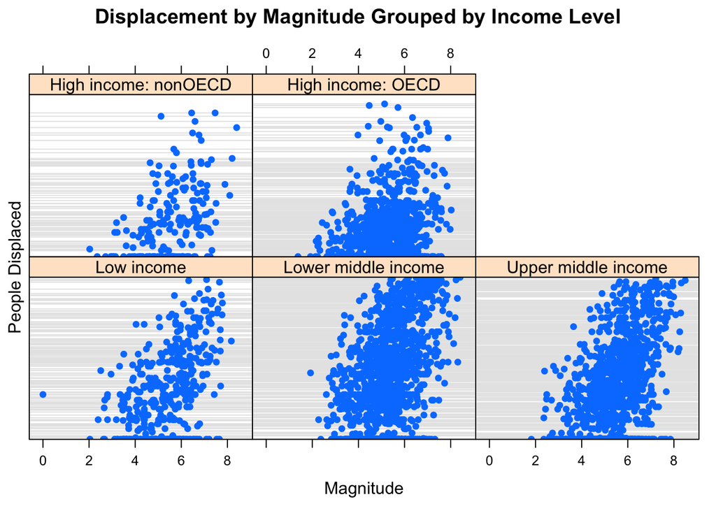

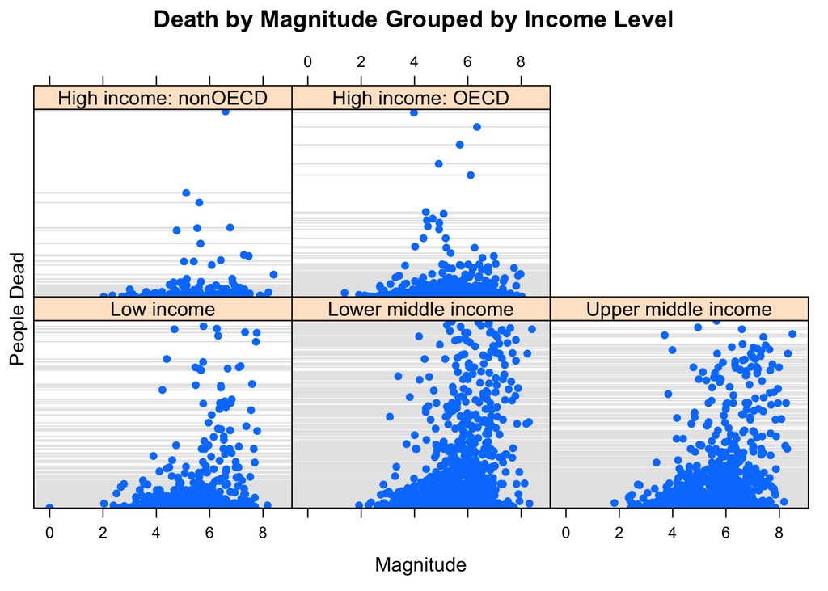

#Displacement

The scatterplot of people displaced for high income is concentrated in the bottom, which means that High Income countries tend to not displace people much regardless of the magnitude of the flood.

In contrast, low income, lower middle income, and upper middle income countries seem to be more middle-heavy. These countries also seem to displace more people as magnitude increases.

# Deaths

The scatterplot of people dead for high income is very bottom-heavy, even more so than in displacement. As income level goes down, we notice that a lot more points are plotted on top. We can quantify this finding further by running a regression analysis by country income level.

```r
lmList(peopleDisplaced ~ magnitude | incomeGroup, data = datc, na.action = na.omit)
```

```
## Call:
##   Model: peopleDisplaced ~ magnitude | incomeGroup
##    Data: datc
##
## Coefficients:
##                      (Intercept)  magnitude
## Low income            -356801.66  81579.940
## Lower middle income  -1822435.25 403441.847
## Upper middle income   -624934.98 137749.151
## High income: nonOECD   -79965.76  17940.510
## High income: OECD      -12639.72   4798.086
##
## Degrees of freedom: 4159 total; 4149 residual
## Residual standard error: 1243627
```

```r
lmList(peopleDead ~ magnitude | incomeGroup, data = datc, na.action = na.omit)
```

```
## Call:
##   Model: peopleDead ~ magnitude | incomeGroup
##    Data: datc
##
## Coefficients:
##                      (Intercept)  magnitude
## Low income            -121.72851  34.940425
## Lower middle income   -642.53399 172.759060
## Upper middle income   -102.40638  52.260055
## High income: nonOECD  -334.65530  79.528348
## High income: OECD       57.91202  -7.579596
##
## Degrees of freedom: 4159 total; 4149 residual
## Residual standard error: 3654.833
```

# Displacement

# Death

Now, let’s look at differing effects of affected area by country income group.

# Size of Affected Area and Displacement/Death

[figure not shown]

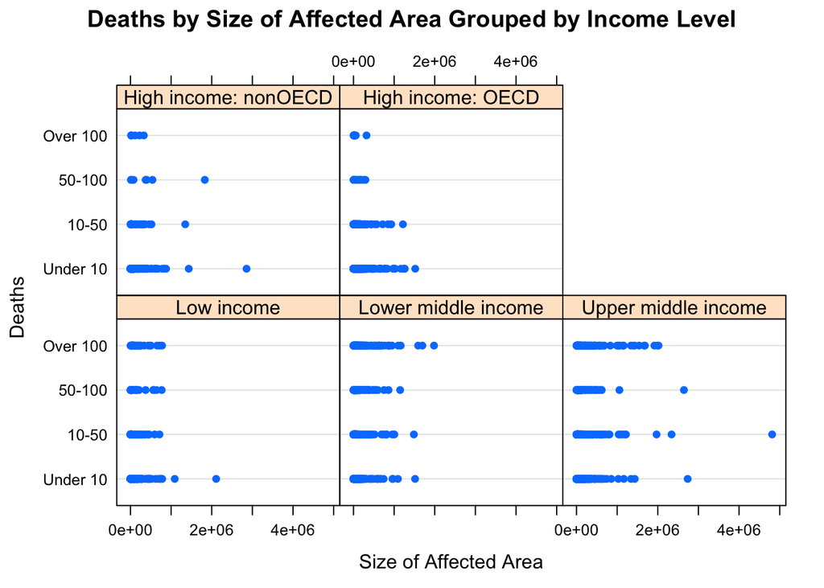

# Displacement

# Death

The correlation between number of people dead and the area of affected region seems to be lower for deaths. Again, for High-OECD countries, the scatterplot is very much bottom-heavy.

```r
lmList(peopleDisplaced ~ affectedSqKm | incomeGroup, data = datc, na.action = na.omit)
```

```
## Call:
##   Model: peopleDisplaced ~ affectedSqKm | incomeGroup
##    Data: datc
##
## Coefficients:
##                      (Intercept) affectedSqKm
## Low income              42097.31   0.39752791
## Lower middle income    157822.82   1.81979411
## Upper middle income     66786.57   0.43434747
## High income: nonOECD    12158.40   0.04800677
## High income: OECD       11032.64   0.01281745
##
## Degrees of freedom: 4159 total; 4149 residual
## Residual standard error: 1253774
```

```r
lmList(peopleDead ~ affectedSqKm | incomeGroup, data = datc, na.action = na.omit)
```

```
## Call:
##   Model: peopleDead ~ affectedSqKm | incomeGroup
##    Data: datc
##
## Coefficients:
##                      (Intercept)  affectedSqKm
## Low income              53.67329  1.252309e-04
## Lower middle income    257.64169  1.865733e-04
## Upper middle income    184.20074 -1.624620e-05
## High income: nonOECD    84.41207  1.539756e-04
## High income: OECD       21.09149 -2.687088e-05
##
## Degrees of freedom: 4159 total; 4149 residual
## Residual standard error: 3656.426
```

The relationship between the size of area affected and number of deaths seems to be much weaker. Interestingly, high income OECD countries and upper middle income countries have a negative relationship between affected square kilometers and number of deaths. While the coefficient is not very large, this can mean that when there are floods that affect large areas, countries predict it and take measures to prevent deaths.

More detailed data can be found when countries are analyzed at a subregion level.

Size of Affected Area

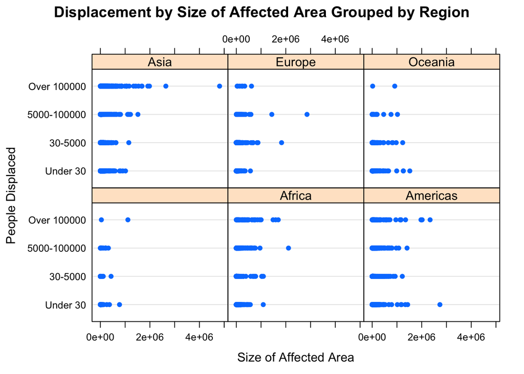

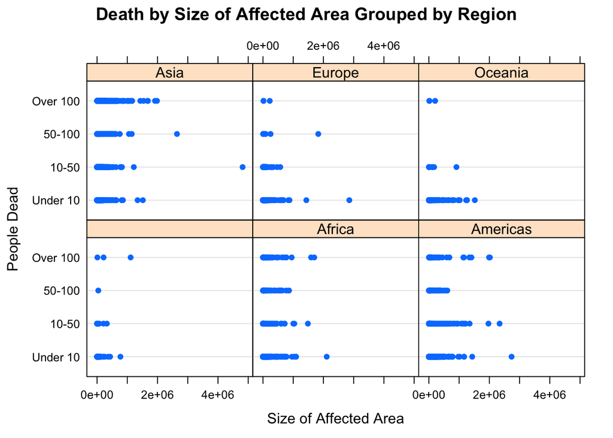

```
## Call:
##   Model: peopleDisplaced ~ affectedSqKm | region
##    Data: datc
##
## Coefficients:
##          (Intercept) affectedSqKm
## Africa    12037.3608   0.24897250
## Americas  49424.3189   0.06443286
## Asia     161151.3399   1.35883160
## Europe     5551.5568   0.02776667
## Oceania     902.1181   0.01021913
##
## Degrees of freedom: 4159 total; 4149 residual
## Residual standard error: 1253528
```

```
## Call:
##   Model: peopleDead ~ affectedSqKm | region
##    Data: datc
##
## Coefficients:
##          (Intercept)  affectedSqKm
## Africa     27.764730  7.218472e-05
## Americas   43.920683  1.220407e-04
## Asia      298.418413  7.263840e-05
## Europe      6.170998  5.818013e-06
## Oceania     2.943687 -1.817857e-07
##
## Degrees of freedom: 4159 total; 4149 residual
## Residual standard error: 3655.381
```

When we look at the number of people displaced for different sizes of areas affected by region, we see that differnet continents have different trends. The regression suggests that Asia displaces the most people and displaces more people as affected area increases. This is probably partly due to the positive relationship between affected area and magnitude as well. Larger affected area means more intense magnitude, which leads to displacing more people. (see regression below)

Oceania seems to displace fewest people as baseline and also doesn’t seem to displace much more people as affected area increases. This can be partly due to the fact that Oceania does not experience floods that cover as much area as Asia, as illustrated by the box and whiskers plot below.

```
##
## Call:
## lm(formula = datc$affectedSqKm ~ datc$magnitude)
##
## Coefficients:
##    (Intercept)  datc$magnitude
##        -526066          118644
```

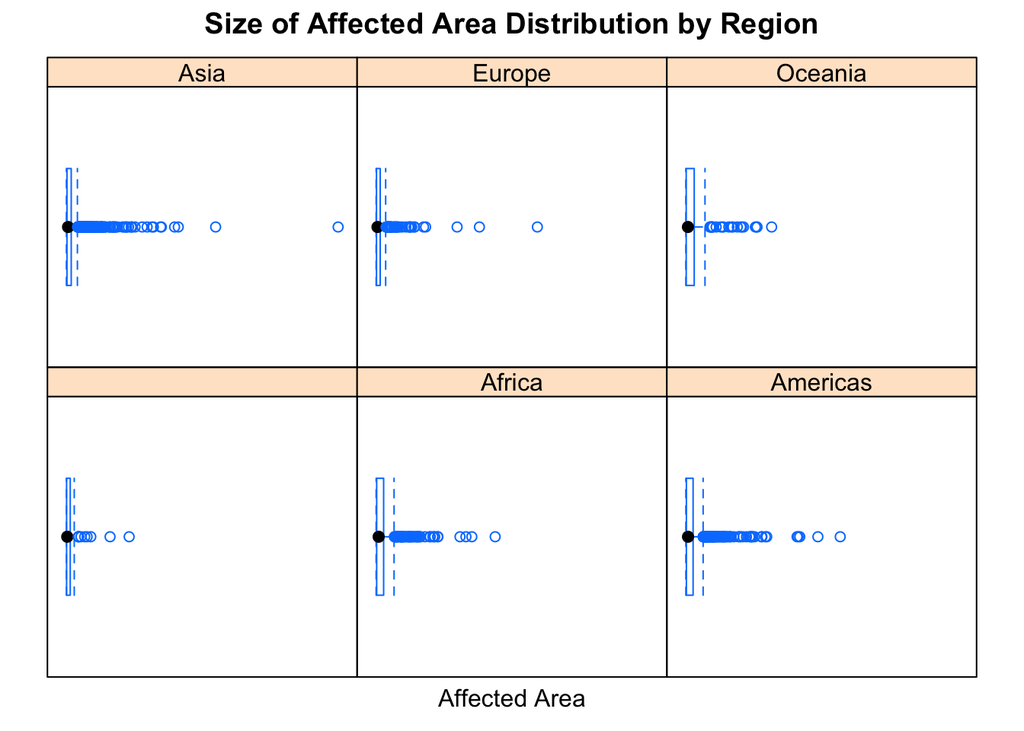

# Magnitudes by Floods of Different Causes

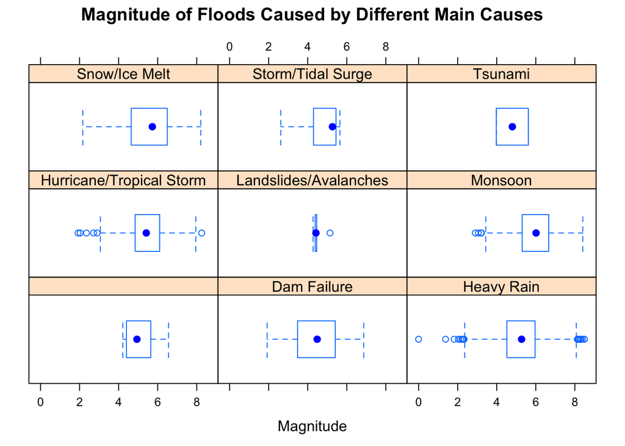

While Landslides and Avalanches seem to cause floods only between magnitudes of 4 and 5, Heavy rain seems to cause floods of varying degrees of magnitudes.

# Size of Affected Areas by Floods of Different Causes

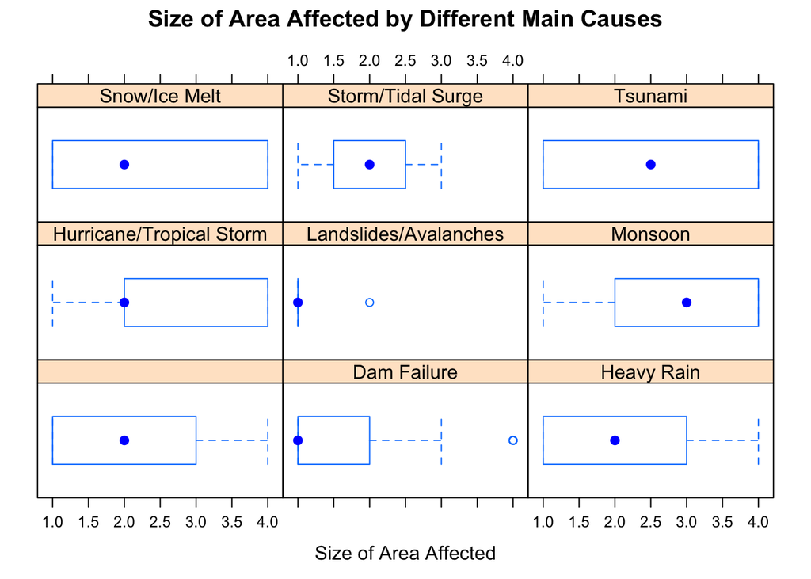

Snow/Ice Melt and Tsunami can affect a wide array of sizes of lands. Landslides/Avalanches seem to usually affect small areas, and Monsoons seem to affect large areas.

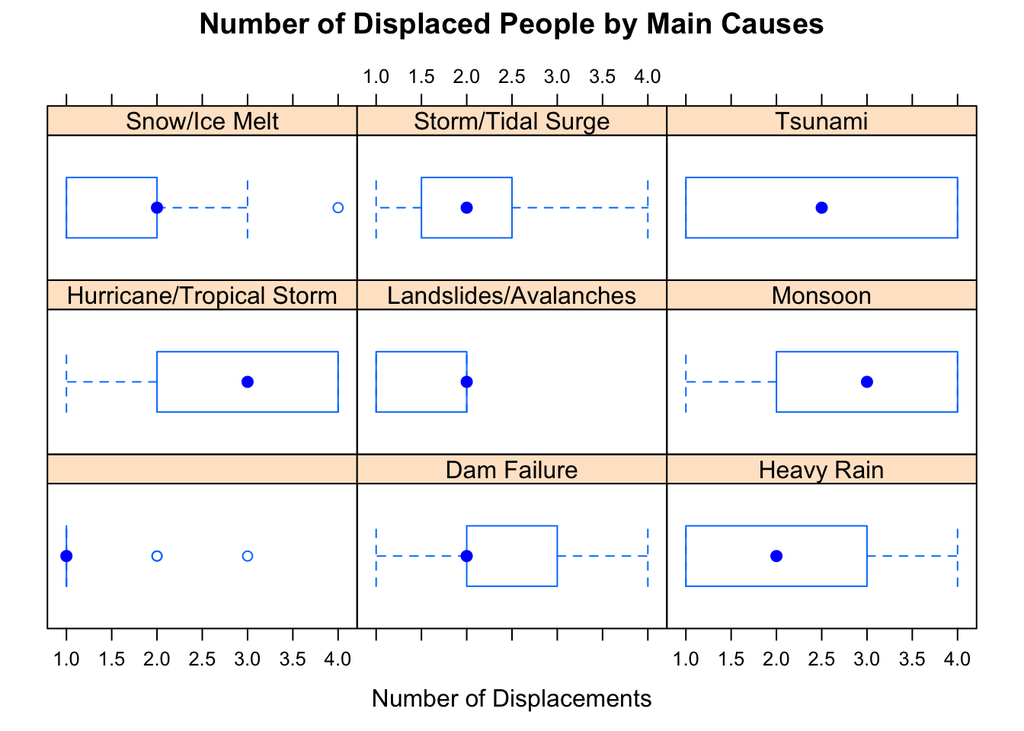

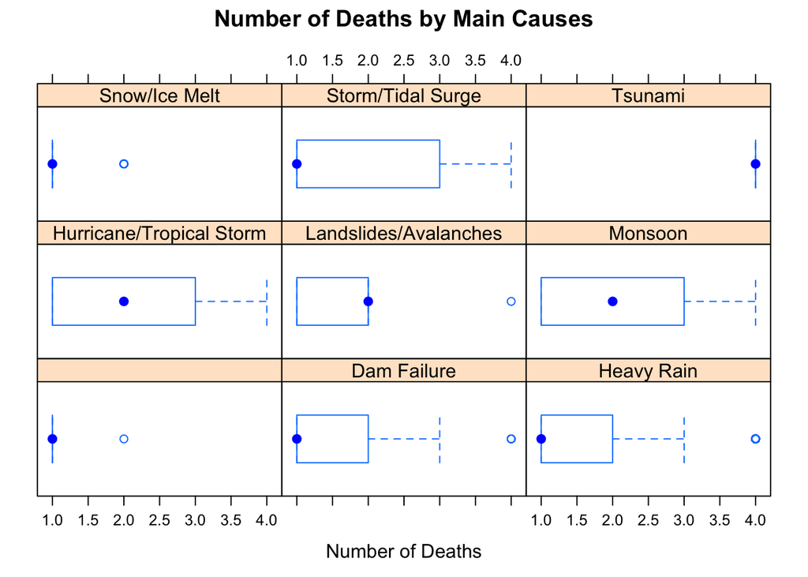

Monsoons and Hurricanes/Tropical Storm seem to displace many people while Landslides/avalanches and snow/ice melt seem to usually displace fewer people. Tsunamis always seem to kill many people, while snow/ice melt seems to always kill only few people.

# Damage Caused by Floods

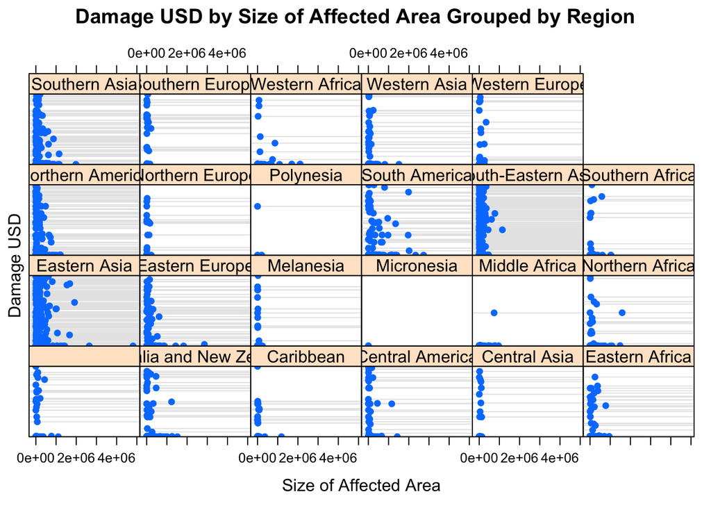

Northern America and Northern Europe seem to have very high starting point of damage in USD probably because since the GDP is high, when damage is done, it is more expensive to recover from the damage. Middle Africa seems to have the lowest starting point in terms of damage in USD.

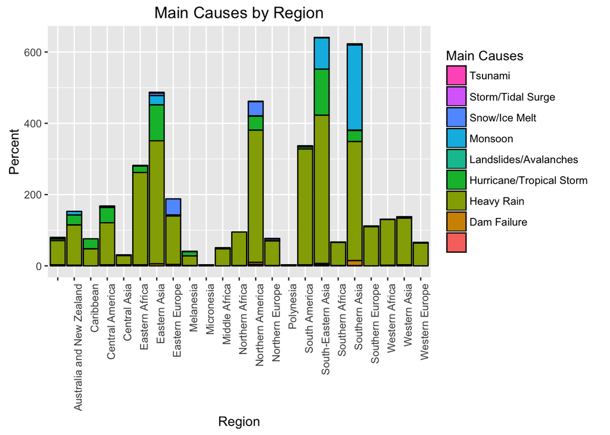

South-Eastern Asia, followed by Southern Asia and then Eastern Asia and Northen America, experience the most number of floods. For each region, over 50% or more floods are caused by heavy rain. In the case of Southern Asia, a large portion of floods are caused by Monsoon. Hurricane/Tropical Storms seem to happen quite often in South-Eastern Asia and Eastern Asia.